### Local Branches Tab

The Local Branches tab gives you the ability to pull, fetch, and merge changes to your current branch, merge local branches into your current branch, switch branches, and create new branches.

Click on the Home icon in the top left of the pane to return to the tab options.

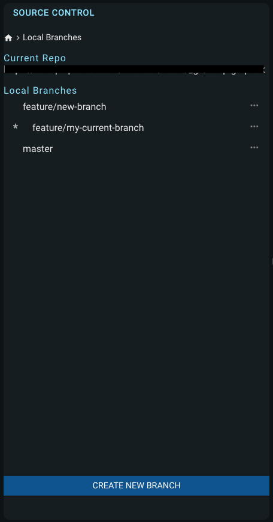

The asterisk next to the branch name indicates the current branch.

#### Fetch, Pull, or Merge

Click on the three dots next to the current branch to fetch, pull, or merge changes into the branch.

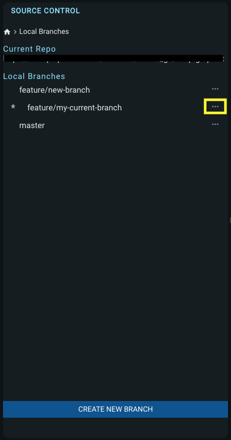

The following modal will appear if a merge conflict occurs when attempting to merge a remote branch into the current branch. Click View Conflicts to begin resolving the merge conflicts, or click Cancel to abort the merge. Click here for more information about merge conflict resolution.

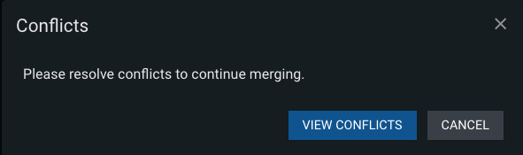

#### Switch Branches

Click on the three dots next to a local branch to checkout the branch

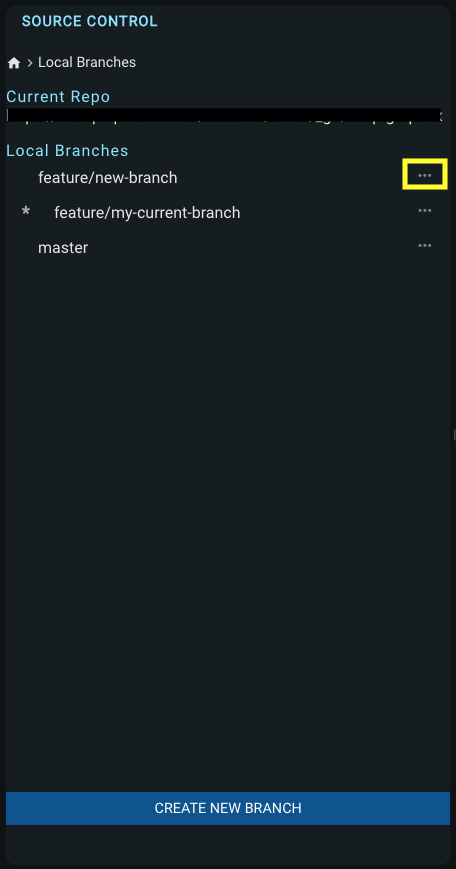

#### Create a New Branch

Click Create New Branch at the bottom of the pane. This will create and checkout the new branch.